# ShinyDataSHIELD User’s Guide

## 3.4 Statistical models

| ⚠️ TABLES USED TO DEMO THIS SECTION |
| --- |
| From https://opal-demo.obiba.org/ : |
| GLM and mixed models STUDY TABLE PROFILE Study1a CNSIM.CNSIM1 default Study1b CNSIM.CNSIM2 default Study1c CNSIM.CNSIM3 default |
| Survival analysis STUDY TABLE PROFILE Study1a SURVIVAL.EXPAND_WITH_MISSING1 survival Study1b SURVIVAL.EXPAND_WITH_MISSING2 survival Study1c SURVIVAL.EXPAND_WITH_MISSING3 survival |

Statistic models are available for tables as well as the following resource types:

- SQL tables
- Tidy data files (tables): `*.csv`, `*.tsv`, etc

There are three different statisticals models available to fit, GLM models (Statistics models tab), GLMer models (Mixed statistical models tab) and Survival cox models (Survival analysis tab).

### 3.4.1 GLM models

The tab to fit a non-disclosive generalized linear models (GLM) contains a box to manually input the formula, a selector for the output family and a table displaying the variables of the data and the type of each variable. There is finally the option to perform a pooled analysis or a meta-study. The possible output families are:

- Gaussian
- Poisson
- Binomial

There’s some help built into ShinyDataSHIELD regarding how to write the GLM formula, which is prompted to the user when clicking on the “Formula input help” button. The display of the variables can be toggled on and off for the convenience of use.

Once the GLM model is fitted a table below the variables display will be rendered with the model results. The download button will prompt a system window to select where to store the shown table, it will save it as a `*.csv`.

When using pooled data, the results of the GLM model will be of the combined data.

(To do: Display more information of why a model fitment fails)

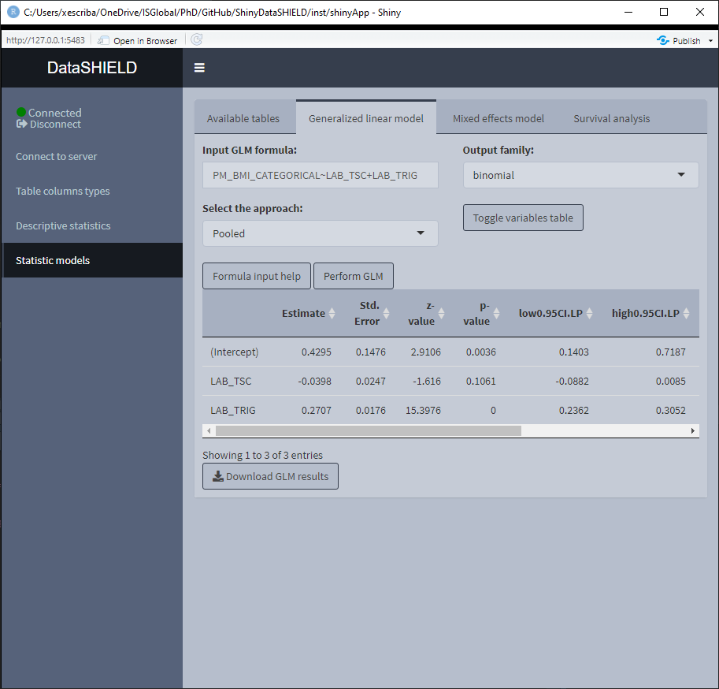

When using a meta-study approach the results correpond to the betas and standard errors for three different meta study methodologies:

- Maximum Likelihood
- REstricted Maximum Likelihood
- Fixed-Effects meta-analysis

This three methodologies can be visualized on a forest plot by selecting the desired one.

[figure not shown]

### 3.4.2 Mixed models

The tab to fit non-disclosive generalized mixed effects models (GLMer) contains a box to manually input the formula, a selector for the output family and a table displaying the variables of the data and the type of each variable. The possible output families are:

- Poisson
- Binomial

There’s some help built into ShinyDataSHIELD regarding how to write the GLMer formula, which is prompted to the user when clicking on the “Formula input help” button. The display of the variables can be toggled on and off for the convenience of use.

Once the GLMer model is fitted a table below the variables display will be rendered displaying the results. The download button will prompt a system window to select where to store the shown table, it will save them as a `*.csv`.

The mixed model results are independent for each study server. There’s a selector to toggle between the results of the different study servers.

(To do: Display more information of why a model fitment fails)

[figure not shown]

### 3.4.3 Survival Analysis

The tab to fit non-disclosive survival analysis is divided into four different subtabs. The first subtab, is used to create a survival object (See the information about `survival::Surv` function for more information https://www.rdocumentation.org/packages/survival/versions/2.11-4/topics/Surv). To create this object, three columns from the selected tables are needed and a parameter:

(Information about each column copied from the `survival::Surv` function documentation)

- Start time variable: for right censored data, this is the follow up time. For interval data, the first argument is the starting time for the interval.
- End time variable: ending time of the interval for interval censored or counting process data only. Intervals are assumed to be open on the left and closed on the right, `(start, end]`. For counting process data, event indicates whether an event occurred at the end of the interval.
- Event variable: The status indicator, normally 0=alive, 1=dead. Other choices are `TRUE/FALSE` (`TRUE` = death) or 1/2 (2=death). For interval censored data, the status indicator is 0=right censored, 1=event at `time` (Start time variable), 2=left censored, 3=interval censored. For multiple enpoint data the event variable will be a factor, whose first level is treated as censoring. Although unusual, the event indicator can be omitted, in which case all subjects are assumed to have an event.
- Type of censoring (parameter): character string specifying the type of censoring. Possible values are “`right`,” “`left`,” “`counting`,” “`interval`,” “`interval2`” or “`mstate`.”

For the data used on this demo, the columns are the following:

- Start time variable: `starttime`
- End time variable: `endtime`
- Event variable: `cens`
- Type of censoring (parameter): `counting`

We have to make sure all three columns are numeric on this demo:

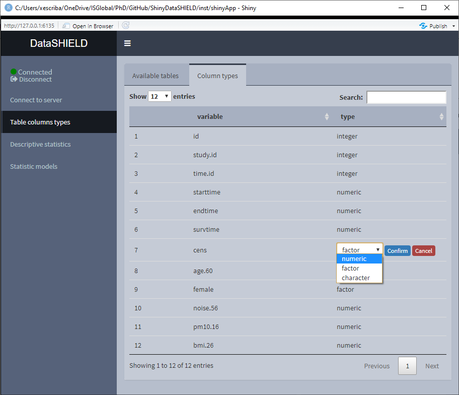

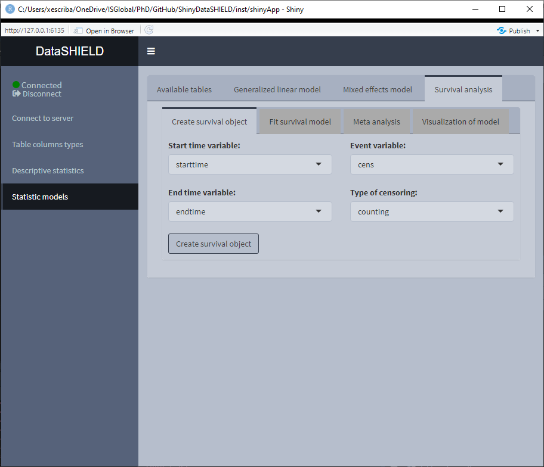

Once the survival object is created, the tab ‘Fit survival model’ is unlocked. On this tab, as with the other statistic models, there is a help button and a ‘Toggle variables tables’ to visualize the variables available to construct the model. The formula has the following structure:

`survival_object~tables_sm$variable+tables_sm$variable2`

Where `survival_object` and `tables_sm` can’t be modified. An example model for this demo data would be:

`survival_object~tables_sm$age+tables_sm$female`

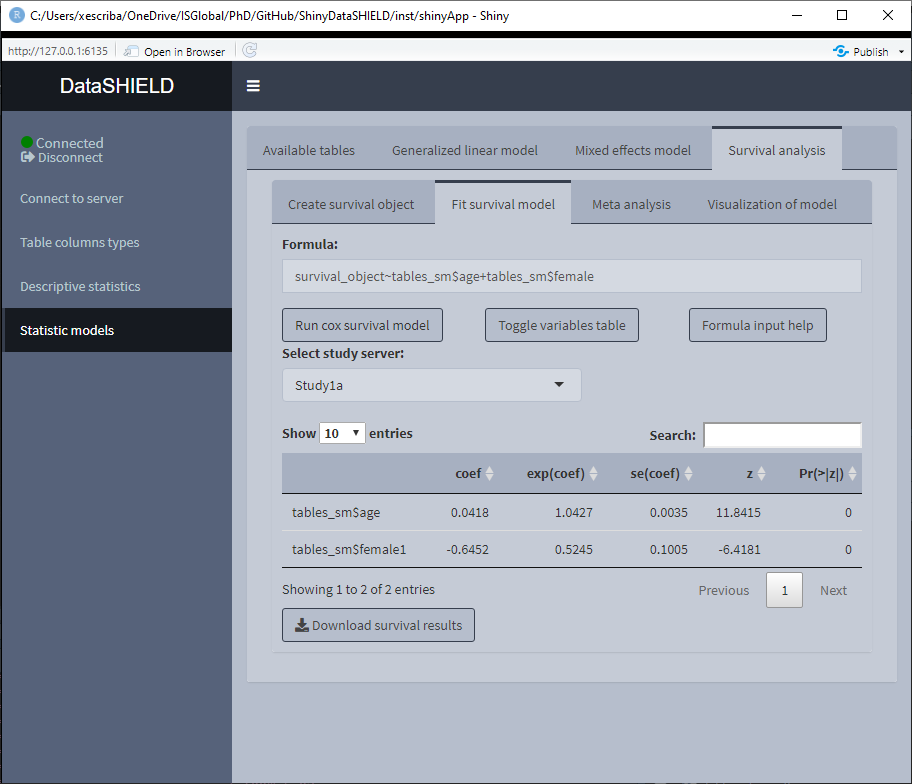

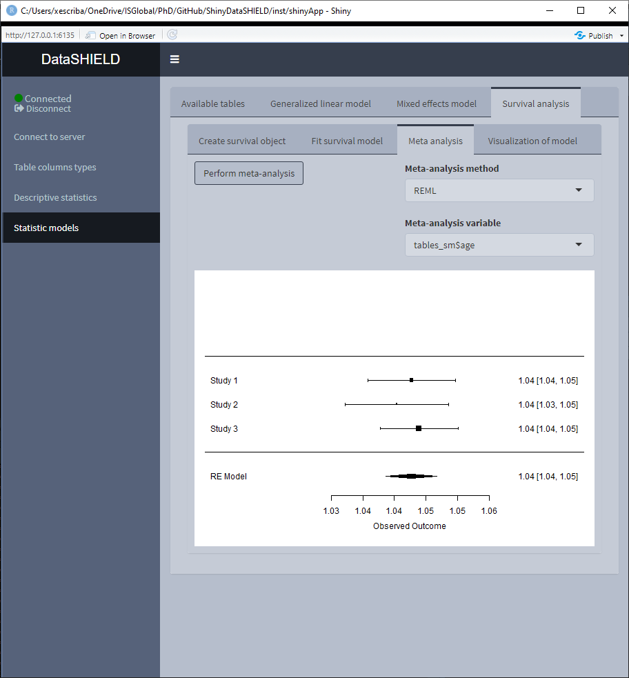

[figure not shown]

## 3.5 Genomics

| ⚠️ RESOURCES USED TO DEMO THIS SECTION |
| --- |
| From https://opal-demo.obiba.org/ : |
| Analysis with BioConductor STUDY RESOURCE PROFILE Study1 RSRC.brge omics Study1 RSRC.brge_vcf omics |
| Analysis with PLINK STUDY RESOURCE PROFILE Study1 RSRC.brge_plink omics |

Inside the genomics tab of dsOmicshiny there are two subtabs, one to perform analysis using BioConductor methods and another to perform analysis using PLINK methods.

### 3.5.1 Analysis with BioConductor

To perform non-disclosive genomic analysis using BioConductor methodologies, the user has to input a VCF resource with a covariates resource (table) on the same study.

When performing this kind of analysis, as explained on the Data Entry section, only one study server can be used.

The Analysis with BioConductor has two sub-tabs, the first one corresponds to the GWAS, and as the name implies is used to perform a GWAS (Genome wide association study) non-disclosive analysis on the loaded data. There is a selector for the condition and the covariates to adjusted for. The fitted model is: snp ~ condition + covar1 + … + covarN. The results of the model appear on a table below the selectors. The download button will prompt a system window to select where to store the shown table, it will save it as a `*.csv`. The second subtab is to display a Manhattan plot of the GWAS results. The dowload plot button saves the shown figure as a `*.png`.

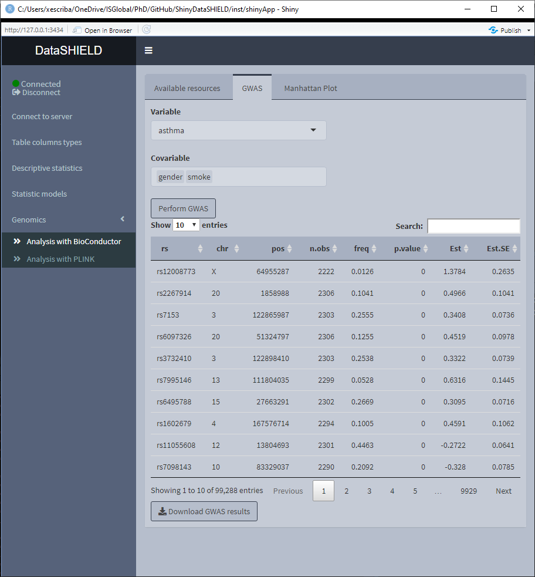

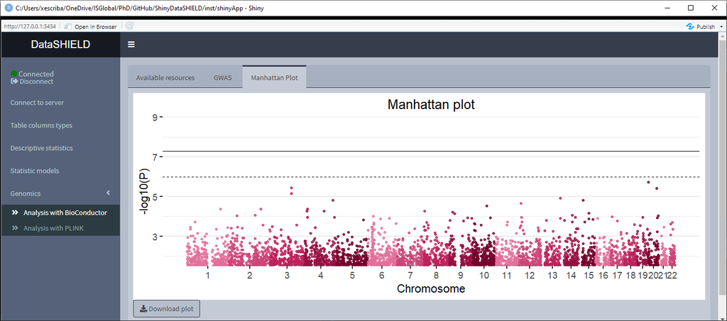

### 3.5.2 Analysis with PLINK

To perform non-disclosive analysis using [PLINK](http://zzz.bwh.harvard.edu/plink/index.shtml) commands, the user has to load a SSH resource. The tab contains a field to input the PLINK command and a brief memo stating that when inputing the PLINK command to run there is no need of inputting it as `plink ...` as would be done on a terminal interface, the user has to input just the `...`; also, there is no need to put `–out` to indicate the output file.

Once the command is run, a table with the results is displayed under the command input, the download button will prompt a system window to select where to store the shown table, it will save them as a `*.csv`. A button to display the raw terminal output appears to display the user on a popup the plain text.

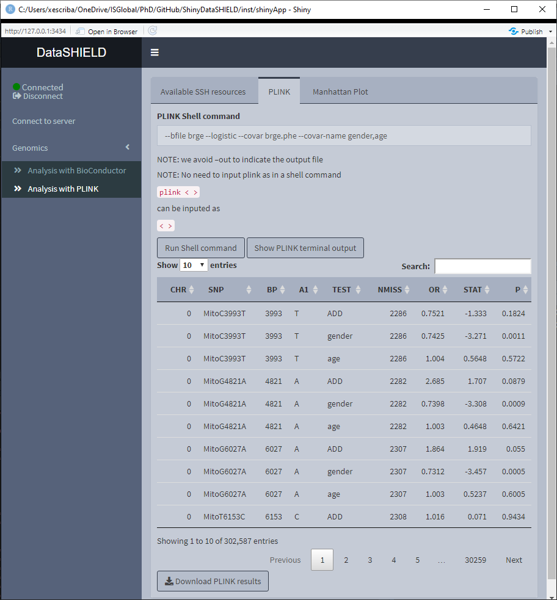

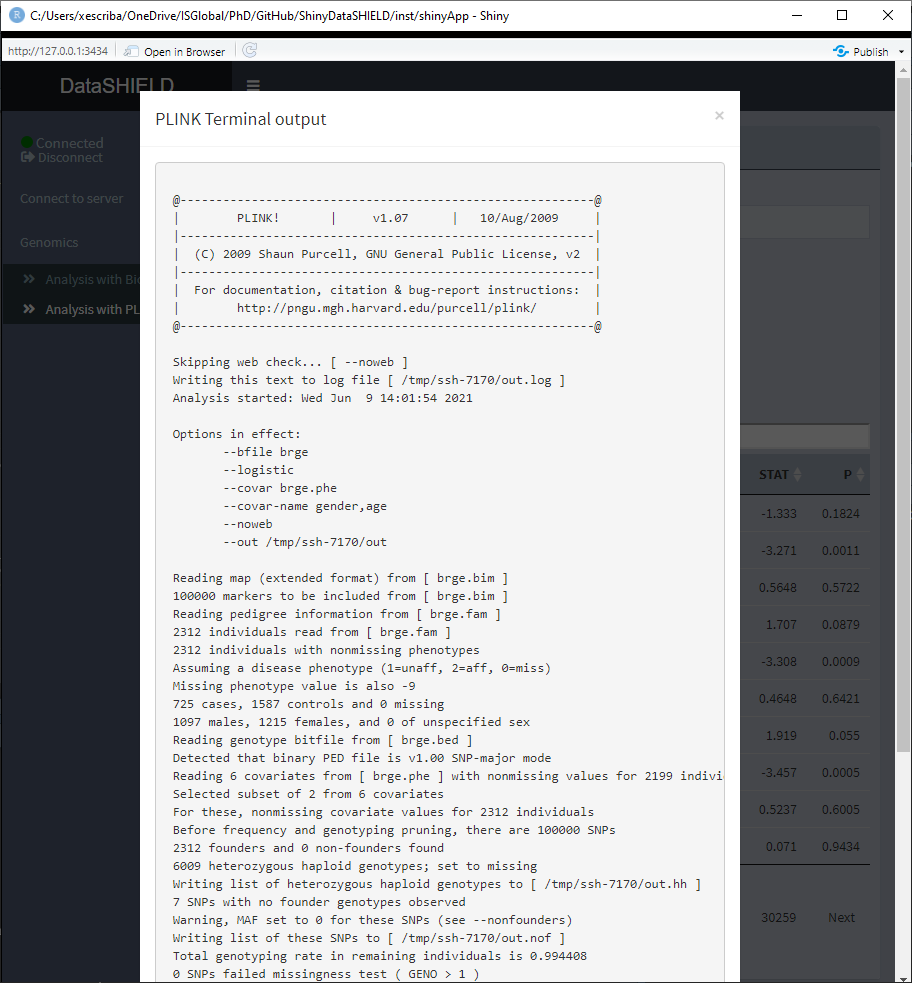

There’s also a sub-tab to show a Manhattan plot with the results obtained. The dowload plot button saves the shown figure as a `*.png`.

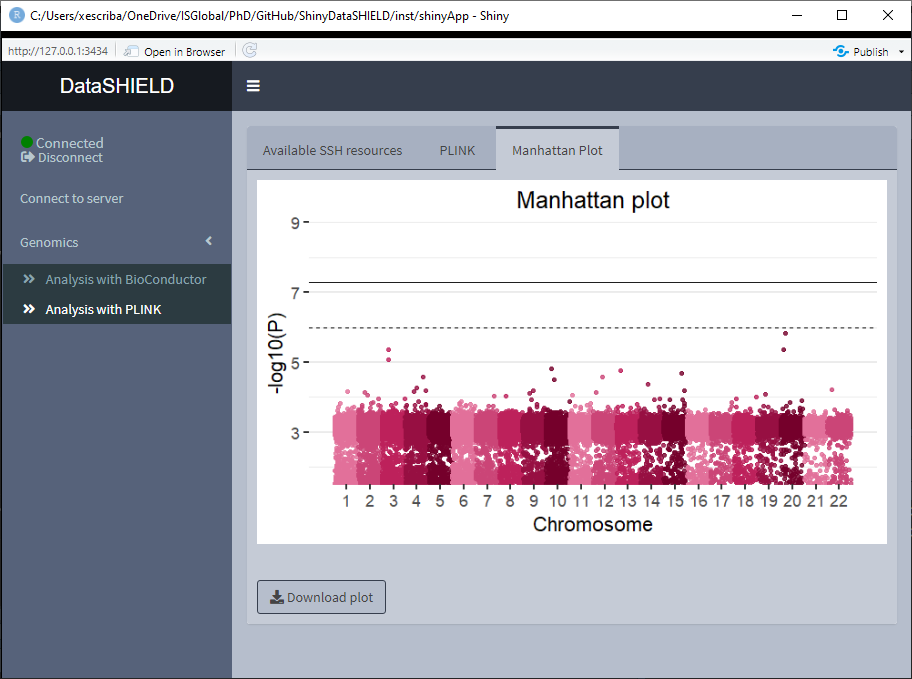

## 3.6 Omics

| ⚠️ RESOURCES USED TO DEMO THIS SECTION |
| --- |
| From https://opal-demo.obiba.org/ : |
| LIMMA STUDY RESOURCE PROFILE Study1 RSRC.GSE80970 omics |
| DESeq and edge R: To be determined |

On the Omics tab there are three different subtabs for different methodologies to perform non-disclosive analysis: limma, DESeq and edgeR. The resources that can be used are ExpressionSets and RangegSummarizedExperiments. If the resources are pooled the user has to input each one in a different study on the data entry.

### 3.6.1 LIMMA

The limma non-disclosive analysis tab contains two selectors to select the condition and covariables of the analysis (resulting formula is: feature ~ condition + covar1 + … + covarN), there’s also a selector to input the annotations columns desired on the output of the analysis. Finally, there’s a selector to indicate the type of data that is being studied, whether is microarray or RNAseq. There’s a selector to choose to do a surrogate variable analysis.

Once the analysis is performed a table with the results is displayed below the parameter selectors. The download button will prompt a system window to select where to store the shown table, it will save them as a `*.csv`.

If the analysis is being performed usging a pooled dataset, the shown table corresponds to all the pooled data.

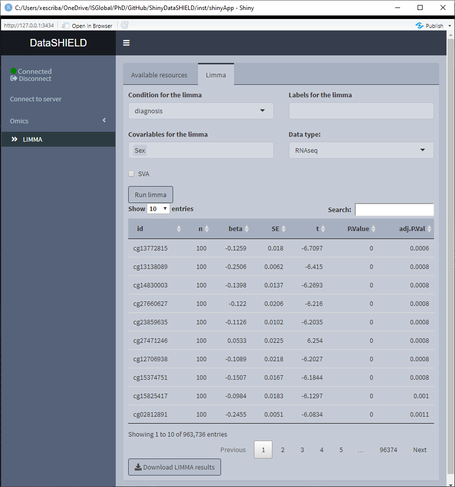

### 3.6.2 DESeq

To be implemented.

### 3.6.3 edgeR

To be implemented.

# 4 Developers Guide

Along this section, documentation for future developers and maintainers of ShinyDataSHIELD is provided. It contains information about how the whole Shiny application is structured, all the different scripts that contains, flowcharts of the different files and information on how to extend the capabilities of ShinyDataSHIELD to new types of resources as well as new methodologies.

| ❗ Observation |
| --- |
| Please read this documentation with the actual source code on the side for easier understanding. |

## 4.1 File structure of ShinyDataSHIELD

Typically Shiny applications are contained in a single file or two files, since the typical structure of a Shiny application is to have a `server` function and a `ui` function that can be on the same file or split for larger applications. On ShinyDataSHIELD the `server` function has been split into different scripts where all of them contains the code of a certain block of the application. It has been done this way to not have a really long `server` file that is difficult to navigate and debug. There is no need to split the `ui` file into different scripts since it only contains the graphical declarations of the applications and is really easy to update and navigate.

The different scripts that compose the whole ShinyDataSHIELD are the following:

- `ui.R`
- `server.R`, composed of the folowing scripts:
  - `connection.R`
  - `descriptive_stats.R`
  - `download_handlers.R`
  - `genomics.R`
  - `omics.R`
  - `plot_renders.R`
  - `statistic_models.R`
  - `table_renders.R`
  - `table_columns.R`

The file `server.R` exists to source the different files and it also includes some small funcionalities.

Now a file per file explanation will be given with flowcharts (when needed), remarkable bits of code explanations and general remarks. Also, details on how to implement new functionalities will be given when needed.

### 4.1.1 `ui.R`

Inside this file there are all the declarations of how the graphical user interface (GUI) will look like.

First, it contains a declaration of all the libraries that have to be loaded for the application to run. The libraries are the following: `DSI, DSOpal, dsBaseClient, dsOmicsClient, shinydashboard, shiny, shinyalert, DT, data.table, shinyjs, shinyBS, shinycssloaders, shinyWidgets, stringr)`.

The next piece of code found

```r
jscode <- '
$(document).keyup(function(event) {
    if ($("#password1").is(":focus") && (event.keyCode == 13)) {
        $("#connect_server1").click();
    };
    if ($("#pat1").is(":focus") && (event.keyCode == 13)) {
        $("#connect_server1").click();
    }
});
'
```

Is a JavaScript declaration that reads as: When the #password1 item (corresponds to the text input of the password on the data entry tab) is active (the user is writting in it) and the “Intro” key is pressed, trigger the #connect_server1 item (corresponds to the “Connect” button on the GUI). That provides the user the typical experience of inputting the login credentials and pressing “Intro” to log in.

It’s important noting that this is only the declaration of a string with the code inside, to actually make use of it, there is the line 58 of this same file that actually implements it.

```r
tags$head(tags$script(HTML(jscode)))
```

Two more pieces of JavaScript and CSS are found

```r
jscode_tab <- "
shinyjs.disableTab = function(name) {
  var tab = $('.nav li a[data-value=' + name + ']');
  tab.bind('click.tab', function(e) {
    e.preventDefault();
    return false;
  });
  tab.addClass('disabled');
}

shinyjs.enableTab = function(name) {
  var tab = $('.nav li a[data-value=' + name + ']');
  tab.unbind('click.tab');
  tab.removeClass('disabled');
}
"

css_tab <- "
.nav li a.disabled {
  background-color: #aaa !important;
  color: #333 !important;
  cursor: not-allowed !important;
  border-color: #aaa !important;
}"
```

The CSS is just for aesthetics, the JS however is to introduce the funcionality of enabling and disabling panels of the web application, this is used as `js$disableTab()` and `js$enableTab()` along the application. Those two scripts are integrated to the application when building the `dashboardBody` by using this

```r
useShinyjs(),
extendShinyjs(text = jscode_tab, functions = c("enableTab", "disableTab")),
inlineCSS(css_tab)
```

There are a some functions used in this file that are worth mentioning:

- `hidden()`: From the `shinyjs` library. The elements wrapped inside of this function will not be rendered by default, they have to be toggled from the server side. Example: A GUI element that needs to be displayed only when a certain condition is met.
- `withSpinner()`: From the `shinycssloaders` library. The elements wrapped inside of this function will be displayed as a “loading spinner” when they are being processed. This is used to wrap figure displays. Example: A plot that is being rendered, it’s better for the user experience to see a “loading spinner” so that it knows something is being processed rather than just staring at a blank screen waiting for something to happen.
- `bsModal()`: From the `shinyBS` library. It’s used to prompt pop-ups to the user. Example: By the click of a button you want to render a pop-up to the application with a figure of an histogram of a selected column of a table.
- `conditionalPanel()`: From the `shiny` library. It is useful to display certain elements on the GUI regarding a condition is met or not, here is used to display the user / password fields or the personal access token (PAT) fields by checking the state of the selector. Note that the condition has to be written using JavaScript, that’s why it looks like `"input.pat_switch1 == true"` rather than the typical R Shiny `input$pat_switch1 == TRUE`.

In order to declare the elements when the user wants to add another server some R tricks are used, they are described and coded on the `connection.R` file.

The rest of this file is your average Shiny functions and declarations, read the official [documentation](https://shiny.rstudio.com/reference/shiny/1.4.0/) for any doubts. Please note that ShinyDataSHIELD uses `shinydashboard` to improve the looks and user experience, for any doubts regarding that please read it’s [documentation](https://rstudio.github.io/shinydashboard/get_started.html).

### 4.1.2 `server.R`

The server file is divided into the following blocks.

- Declaration of reactiveValues: As a code practice measure, all the variables that have to be used in different parts of the code (Example: Table that contains the information about the loaded resources, has to be written when loading the data and afterwards to check whether a resource has been loaded or not) are reactive values. The only occassions where there are “regular” variables are inside functions that use variables as placeholders to be used only inside of that function (Example: Storing the results of a middle ground operation to be later used inside the same function to perform the final analysis, whose results will be saved on a reactive value variable). Developers used to lower level languages can see this as `public` and `private` variables.
- Sourcing of scripts: Sourcing all the different scripts that actually make up `server.R`. As said before this is done this way to have a more structured application where each script takes care of a certain block of the application.
- Disabling of all the tabs except the server connector: By default all the tabs are visible on Shiny, in order to provide a good user experience all are disabled at the launch of the application using `js$disableTab()`, once tables or resources are loaded into the study servers tabs are enabled (only the ones that makes sense, if the user loads a Table, only the tabs to interacts with tables will be enabled).
- Function declaration: Declaration of a function that given a column of a data table will truncate the decimal places to 4, it’s used when rendering tables to not have tables with 9 decimals that look hideous.
- Functions to manage the “Connected” / “No connection” display. It’s a bunch of logic and CSS to just control a small element of the GUI. Basically if the variable `connection$active` is `TRUE` the GUI will show “Connected” next to a green dot with a “Disconnect” button, otherwise it will display “No connection” next to a red dot. When the button “Disconnect” is pressed, the function to log out of the server is triggered and the `connection$active` variable is set to false.
- Stop function: This delcaration is left for future developers. When having trouble on a certain spot, add a stop button using `actionButton("stop", "stop")`, press it on the GUI to stop the execution and perform the required debugging.

The scripts sourced for by the `server.R` are the following:

#### 4.1.2.1 `connection.R`

This is probably the most important script of the whole application, as it’s the one that is responsible for loading the data in order to ensure that the application capabilities can be extended in the future painlessly (modular).

Inside this script there are five different sections that are triggered by different actions:

1. Creation of GUI for the new server tabs
2. Creation of `observeEvents` for all the different server tab elements.
   1. URL builder to display selected items on a browser
   2. Connection to the server to obtain the projects and resources. Triggered by the button with label “connect_server.”
   3. Get tables / resources from the selected project. Triggered everytime the selector with label “project_selected” is changed.
   4. Add a study. Triggered by the button with label “add_server.”
3. Remove a server tab. Triggered by the button with label “remove.”
4. Remove a study item Triggered by the button with label “remove_item.”
5. Load the selected studies to the study servers. Triggered by the button with label “connect_selected.”

The first element to explain is the creation of the new server tabs (Point 1, `observeEvent(input$add, {})`). It’s just a matter of noting two things to understand it easily, 1) The use of a reactive value `tabIndex()` which returns a integer (initialized at `1`), this integer corresponds to the tab being created (hence it’s updated at the top of the call); 2) The rest of the call is an `appendTab()` that adds a new tab on the element id `"tabset1"` with the exact structure of `ui.R` but changing the element IDs using the reactive value so that all the buttons/input fields are numbered according to the tab they are located on. When removing a server tab (`observeEvent(input$remove, {})`) the tab itself is removed using `removeTab()` and the reactive value is actualized.

The creation of `observeEvents` for all the different server tab elements (Subitems of point 2) is done using a small trick. `max_servers` number of `observeEvents` are created (using `lapply`) for the different functionalities so that all the server tabs are functional, this integer variable is defined on the script `server.R`, if more servers than the default (10) are required just update the definition of the variable and relaunch the application.

The last part of the script, loads all the selected tables and resources to the selected study servers. It does everything needed to each particular type of resource, that means converting them to R objects or to tables depending on what they are.

When loading the selected resources or tables into the study servers, the table `available_tables` is created. The name is a little bit confusing since it actually contains the information about tables and resources, the developer apologizes as this variable was set at the beginning of the development and has not been updated. Nevertheless, it’s an important variable of the application, the structure of this table is the following.

| Column | Description |
| --- | --- |
| name | Name of the object (`project.name`) |
| server_index | Index of the study server that contains the table/resource |
| server | Name of the study server |
| type_resource | Type of the resource |

The Opal server can host different types of resources, to name a few there are `ExpressionSet`, `RangedSummarizedExperiment` and `SQLResourceClient`. Each type of resource needs a special treatment to be used, for example `SQLResourceClient` resources are plain tables, so they need to be converted to tables on the study server to use them. Currently the following resource types are supported by ShinyDataSHIELD.

| Resource type | Treatment | Name of the resource type on `available_tables` |
| --- | --- | --- |
| TidyFileResourceClient, SQLResourceClient | - `as.resource.data.frame(resource)` - Append `.t` to the name | `table` |
| SshResourceClient | Append `.r` to the name | `ssh` |
| GdsGenotypeReader | - `as.resource.object(resource)` - Append `.r` to the name | `r_obj_vcf` |
| ExpressionSet | - `as.resource.object(resource)` - Append `.r` to the name | `r_obj_eset` |
| RangedSummarizedExperiment | - `as.resource.object(resource)` - Append `.r` to the name | `r_obj_rse` |
| Any other resource type | - `as.resource.object(resource)` - Append `.r` to the name | `r_obj` |

`.r` and `.t` are appended to the resources to allow a resource and a table on the same project to have the same names and not crash the Shiny application.

Now, let’s look at some examples to add new resource types on the `connection.R` file. There are different cases for the treatment that the new resource requires.

- Resources that just need to be loaded with no further action performed to them (same treatment as SSH connections). Add another `else if` statement after line 303. Example: New resource called `Simple_resource`

```r
else if ("Simple_resource" %in% resource_type){
            # Update available_tables list with the new resource type name
lists$available_tables <- rbind(lists$available_tables, c(name = name, server_index = server_index,
                                                                      server = resources$study_server[i], type_resource = "Simple_resource"))
          }
```

- Resources that need to be converted into R objects (`datashield.assign.expr(conns, symbol = "methy", expr = quote(as.resource.object(res)))`) and nothing else. Will work out of the box (the `type_resource` column of the `lists$available_tables` table will read `r_obj`).
- Resources that need to be converted into R objects (`datashield.assign.expr(conns, symbol = "methy", expr = quote(as.resource.object(res)))`) and be further processed. Add another `else if` statement after line 320. Example: A new type of resource called `special_resource` that contains some variable names that are desired to be saved on a variable to feed a list on the GUI.

```r
else if("special_resource" %in% resource_type) {
              # Update available_tables list with the new resource type name
  lists$available_tables <- rbind(lists$available_tables, c(name = name, server_index = server_index,
                                                                        server = resources$study_server[i], type_resource = "special_resource"))
              # Perform the needed actions for this resource
              [...]
            }
```

Finally, once all the connections have been successful, and all the selected tables and resources are loaded, the tabs that make use of the loaded objects are enabled by using (table examples)

```r
if(any(unique(lists$available_tables$type_resource) %in% c("table"))) {
        show(selector = "ul li:eq(2)")
      }
```

There are many `if` that checks for type of resources and enables tabs if present, on the previous example the second tab `ul li:eq(2)` (there is no way of refering them by ID as far as I know to perform this action) is enabled because it contains a module that works with tables.

If a new type of resource is implemented, add after line 353 (tab 10 is just as example)

```r
if(any(unique(lists$available_tables$type_resource) %in% c("new_resource"))) {
        show(selector = "ul li:eq(10)")
      }
```

Also update this part if a new module is added, make sure to enable the tab only when the resources that the module use are present on the `lists$available_tables`.

### 4.1.3 Structure of the modules

A common structure is followed for all the different modules, this refers to the general structure of `descriptive_stats.R`, `statistics_models.R`, `genomics.R`, `omics.R` and `table_columns.R`.

Before describing the internal structure of the modules, let’s briefly describe the GUI structure, which is also common between them. The tabs are filled with a tab box, the first element is always a table with the available tables / resources for that module. For example, the Omics module only displays the resources of type RSE or eSet. The other tabs are disabled by default and can only be accessed once the user has selected which resource to use. Now let’s talk about how to accomplish all of this.

At the beginning of all the modules there is an `observeEvent` that is triggered when the user selects an item from the table. The structure of this is the following

```r
observeEvent(input$table, {
  if(length(input$table_rows_selected) > 0){ # Check if the user has selected any row
    different_study_server <- TRUE # On this example we are checking that everything selected is on different study servers
    same_cols <- TRUE # On this example we are checking tables to be pooled, so we are checking they have the same columns
    if(length(input$table_rows_selected) > 1){ # If more than one table is selected the checks have to be performed, otherwise there is no need to check for same cols or different study servers
      same_cols <- all(lapply(input$tqble_rows_selected, function(i){
        res<-all(match(lists$resource_variables[[as.character(lists$available_tables[type_resource %in% c("table")][i,1])]],
                       lists$resource_variables[[as.character(lists$available_tables[type_resource %in% c("table")][1,1])]]))
        if(is.na(res)){FALSE} else{res}
      }))
      different_study_server <- nrow(unique(lists$available_tables[input$table_rows_selected,3])) ==
        length(input$table_rows_selected)
    }
    if(same_cols & different_study_server){ # If both tests are OK, remove the "resource_lim" object from the study servers
      datashield.rm(connection$conns, "resource_lim")
      for(i in input$table_rows_selected){
        lists$available_tables[type_resource %in% c("table")][i,2]
        # Then assign the selected tables to a new variable on the study servers called "resource_lim", this is the variable that all the other funcionalities of the module will refer to when performing analysis
        datashield.assign.expr(connection$conns[as.numeric(lists$available_tables[type_resource %in% c("table")][i,2])], "resource_lim", as.symbol(as.character(lists$available_tables[type_resource %in% c("table")][i,1])))
      }
      # Enable the analysis tab and update the GUI to display it
      js$enableTab("tab_of_analysis")
      updateTabsetPanel(session, "id",
                        selected = "tab_of_analysis")
    }
    else{ # If the tests fail, display an error message
      shinyalert("Oops!",
                 if(!same_cols){
                   "Selected resources do not share the same columns, can't pool unequal resources"
                 }else{
                   "Selected resources are not on different study servers, can't pool resources on the same study server."
                 }
                 , type = "error")
      # Make sure analysis tabs are disabled and the GUI shows the selection tab, this is important to do because if the user first selects a valid table and then an invalid combination, we want to make sure that the user has no longer access to the analysis tab
      js$disableTab("tab_of_analysis")
      updateTabsetPanel(session, "id",
                        selected = "table_selection")
    }
  }
})
```

This example can be extended to the developers needs, but as a structure example is more than enough. Please read the source code for the available modules if extra examples are needed.

The body of the modules correspond to whatever is needed on that module, let that be some `observeEvent` for buttons of the analysis tab, some `renderUI` for dynamic selectors or anything other that the module needs.

The bottom of the modules is also shared, they contain an `observe` clause that is triggered when the tab is selected, it has the following structure

```r
observe({
  if(input$tabs == "id") { # The ID here corresponds to the tabname declare on the ui.R ; tabItem(tabName = "ID", .......
    tables_available <- lists$available_tables[type_resource %in% c("table")] # Input here the type_resource that this module uses, so only those are displayed
    if(length(lists$resource_variables) == 0){
      withProgress(message = "Reading column names from available tables", value = 0, {
        for(i in 1:nrow(tables_available)){ # In this example we are reading table columns so that when the user selects from this table, we can automatically check if the columns are shared when trying to pool tables, this is done on the header of the module, that we have just seen
          lists$table_columns[[as.character(tables_available[i,1])]] <- ds.colnames(as.character(tables_available[i,1]), datasources = connection$conns[as.numeric(tables_available[i,2])])[[1]]
          incProgress(i/nrow(tables_available))
        }
      })
    }
    # Finally we render the table with the available tables for this module so the user can select which ones to use, of course this needs to be completed on the table_renders.R (following chunk has an example)
    output$available_tables_sm <- renderUI({
      dataTableOutput("available_tables")
    })
  }
})
```

Example of the code for the table_render.R regarding the selection table

```r
output$available_tables <- renderDT(
  lists$available_tables[type_resource == "table"], options=list(columnDefs = list(list(visible=FALSE, targets=c(0,2,4))),
                                                                 paging = FALSE, searching = FALSE)
)
```

Now let’s take a look at the scripts that are used by all the modules, their use is to render tables, figures and handle the downloads (figures + table downloads)

#### 4.1.3.1 `table_renders.R`

This script creates the displays of all the tables of ShinyDataSHIELD, it uses the `DT` package to do so. Besides the `descriptive_summary` table, all the other tables just render results from other functions.

There are some things to point of this script:

- As can be seen in `descriptive_summary` table, you can actually perform operations inside of a `renderDT` function and display the result of them.
- The most used options for the tables aesthetics are the following

```r
options=list(columnDefs = list(list(visible=FALSE, targets=c(0))),
                                          paging = FALSE, searching = FALSE)
```

This prevents the `rownames` column to be displayed (usually it just contains the numeration of rows 1…N, be aware sometimes it’s of interest to see this column) and eliminates the paging and searching functionalities of the table. For small tables it makes sense to not show that but on big tables those options are set to `TRUE`, as it’s very useful to have a search box on them.

- The tables that display numerical columns (mixed or not with non-numerical columns) are actually passed through the `format_num` function (defined on `server.R`) so the displayed table has only four decimals but the actual table (the one that can be saved) has all the decimals. This is done using the following code

```r
as.data.table(lapply(as.data.table(vcf_results$result_table_gwas$server1), format_num))
```

This will pass each column to the function and if it’s numerical the decimals will be cut to 4.

- The table output structure of the LIMMA results look different than the others, this is because when performing a LIMMA with pooled resources it returns one table for each study, what is being done is just binding them to display to the user all the obtained results.

There is a concrete render that needs a special mention on this documentation, that is the `column_types_table`, which uses the CellEdit JavaScript plugin to enable drop down menus when editing a table. Let’s see what is being done

```r
tab <- datatable(
      table_to_be_modified, editable = "cell", callback =  # The callback needs to be updated to include the JS custom code
        JS(
          "function onUpdate(updatedCell, updatedRow, oldValue){",
          "Shiny.onInputChange('jsValue', [updatedCell.index(), updatedCell.data()]);", # The results to actually update the table_to_be_modified on the module script will be retrieved by a observeEvent(input$jsValue, { ; change jsValue each time this approach is used to avoid collisions
          "}",
          "table.MakeCellsEditable({",
          "  onUpdate: onUpdate,",
          "  inputCss: 'my-input-class',",
          "  columns: [2],",
          "  confirmationButton: {",
          "    confirmCss: 'my-confirm-class',",
          "    cancelCss: 'my-cancel-class'",
          "  },",
          "  inputTypes: [",
          "    {",
          "      column: 2,",
          "      type: 'list',",
          "      options: [",
          "        {value: 'numeric', display: 'numeric'},", # Update this lines to declare the options of the dropdown
          "        {value: 'factor',      display: 'factor'},",
          "        {value: 'character',    display: 'character'}",
          "      ]",
          "    }",
          "  ]",
          "});"),
      options = list(pageLength = nrow(table_to_be_modified))
    )
    path <- "../../www/" # folder containing the files dataTables.cellEdit.js
    # and dataTables.cellEdit.css, they are already included on ShinyDataSHIELD, so there is no need to worry about that
    dep <- htmltools::htmlDependency(
      "CellEdit", "1.0.19", path,
      script = "dataTables.cellEdit.js", stylesheet = "dataTables.cellEdit.css")
    tab$dependencies <- c(tab$dependencies, list(dep))
```

Example of what to include on the module script to update the table

```r
proxy = dataTableProxy('a') # No need to change this
observeEvent(input$jsValue, { # As stated above, the trigger is actually the value defined on the callback, we can retrieve the row, column and value from that object
  change <- data.table(input$jsValue)
  row <- as.numeric(change[1,1]) + 1
  column <- as.numeric(change[2,1])
  value <- as.character(change[4,1])

  table_to_be_modified[row, column] <<- value
  replaceData(proxy, table_to_be_modified, resetPaging = FALSE)
}
```

#### 4.1.3.2 `plot_renders.R`

There are two types of plots on ShinyDataSHIELD, the ones created with the base function plot and the ones created with the [ggplot](https://ggplot2.tidyverse.org/) library. In order to later recover the plots to download them, they actually have a different structure.

- Base plot structure:

```r
output$random_plot <- renderPlot({
  plots$random_plot <- function(){
    function_that_generates_the_plot_using_base_package(arguments)
  }
  plots$random_plot()
})
```

For the base plots, a function is declared that returns the plot and is called to generate the plot to the GUI.

- Ggplot structure:

```r
output$manhattan <- renderPlot({
  plots$ggplot <- function_that_generates_the_plot_using_ggplot2_package(arguments)
  plots$ggplot
})
```

In this case the plot is saved, ggplot will generate a plot variable that can be called to render the plot.

On this script there are two plots that are inside a `renderCachedPlot` function instead of a `renderPlot` because they take really long to calculate and it’s better to cache them.

Inside of the `renderPlot` function some other code can be put, such as toggles to GUI elements or `tryCatch()` functions.

#### 4.1.3.3 `download_handlers.R`

In this script everything related to downloading plots and tables is found. There are basically three types of structures

- Table downloader: To download a `*csv`. Structure:

```r
output$table_download <- downloadHandler(
  filename = "table.csv",
  content = function(file) {
    write.csv(
      variable_that_contains_table
      , file, row.names = FALSE)
  }
)
```

The `row.names = FALSE` argument may not be needed in tables where the row names are important.

- Base plot downloader: To download a `*.png`. Structure:

```r
output$base_plot_download <- downloadHandler(
  filename = "base_plot.png",
  content = function(file) {
    png(file = file)
    plots$base_plot()
    dev.off()
  }
)
```

Basically this calls the previously declared function and captures the plot into a `*.png`.

- GGplot downloader: To download a `*.png`. Structure:

```r
output$ggplot_download <- downloadHandler(
  filename = "ggplot.png",
  content = function(file) {
    ggsave(file, plot = last_plot())
  }
)
```

When using ggplot, the function `last_plot()` renders the last plot rendered by ggplot. This only has one inconvenient, that is when you are downloading a plot that takes a while to render, the application doesn’t show the save window dialog until it has rendered again. This should be addressed in the future as it really halters the user experience.

### 4.1.4 How to add a new block

To add a new block to ShinyDataSHIELD, the developer has to create a new `*.R` script inside the `inst/shinyApp/` folder of the project and give it a descriprive name of the function that it will perform.

So the Shiny application actually sees it, the `server.R` needs to be updated and source the new file. Example: New block called `new_analysis.R`, the update to the `server.R` will be

```r
source("new_analysis.R", local = TRUE)
```

Afterwards, the `ui.R` can be updated by defining how the new block will be presented to the user. The `sidebarMenu` function needs to be updated so that the new tab appears on the sidebar of the application, follow the structure of the other tabs. Afterwards update the `dashboardBody` function by defining all the different elements of the new tab, follow the structure of the other available tabs to follow the general design lines, all the functions that need to be used here are standard Shiny functions mostly and there’s plenty of documentation and examples available online, when in doubt just try to copy an already implemented structure.

Now the user can focus on the types of files that will feed this new block, if it’s a table there’s no need to worry, if it’s a resource that is not implemented the `connection.R` needs to be updated. Read the above documentation for guidance on the changes that need to be done for new resources types.

Once the GUI is setup and the table / resource that this block will use is setup, the backend for this block can be built on the `new_analysis.R` file. Include on that file all the required `renderUI()` functions and steps to process the file and analyze it. Probably a new variable will be required to hold the results, update the `server.R` header and include a new `reactiveValues()` declaration for the new block.

If the new block requires to display tables or figures, update the `table_renders.R` and `plot_renders.R` following the given examples on their sections of the documentation. Make sure to include the download buttons for them on the `download_handlers.R`.

If there is some part of the code that takes some time to process, there’s the option of wrapping it inside the `withProgress()` function in order to display a loading annimation to the GUI to alert the user that something is being processed.

Make sure to include the custom implementation of the header and footer functions for the module that have been presented before.

When developing a new block there will probably be many problems occurring, in order to debug a Shiny application there is the `browser()` function, if the developer is getting some sort of error at X line of the script, just write `browser()` on the line adobe of the error, the execution will be stopped at that point and the developer can interact with all the available variables of the environment through the RStudio console, usually running the line that is giving an error on the console will provide enough information to kill the bug. If the line breaking is a function call it is advisable to type the variables that are being passed into the function on the console, that way the developer can see what exactly is being passed and can see that some argument is `NULL` when it shouldn’t or it’s a character when it should be a number, those are quite common problems.

When a new block is developed and integrated into ShinyDataSHIELD, please conclude it by updating this documentation and the user guide with a brief explanation of the new block and some remarks of the most interesting bits of it.